# Select only the records corresponding to failed inspection (see "results" column)

```python
# import data
import csv
import pandas as pd
df = pd.read_csv('Food_Inspections_20240108.csv')
df.head(10)
```

|  | Inspection ID | DBA Name | AKA Name | License # | Facility Type | Risk | Address | City | State | Zip | Inspection Date | Inspection Type | Results | Violations | Latitude | Longitude | Location |
| --- | --- | --- | --- | --- | --- | --- | --- | --- | --- | --- | --- | --- | --- | --- | --- | --- | --- |
| 0 | 2587633 | TACOS MARIO'S LIMITED | TACOS MARIO'S LIMITED | 1447643.0 | Restaurant | Risk 1 (High) | 4540 W 63RD ST | CHICAGO | IL | 60629.0 | 01/04/2024 | Non-Inspection | No Entry | NaN | 41.778606 | -87.736592 | (41.77860614662516, -87.73659163763277) |
| 1 | 2587625 | TAQUERIA EL ARCO #3 EL POLLO FELIZ, INC. | EL POLLO CRIS CRIS #3 | 1964458.0 | Restaurant | Risk 1 (High) | 7023-7025 S PULASKI RD | CHICAGO | IL | 60629.0 | 01/04/2024 | Canvass | Out of Business | NaN | 41.765126 | -87.722279 | (41.765126421774134, -87.72227898862089) |
| 2 | 2587598 | Tel Aviv Slices Pizza LLC | Tel Aviv Slices Pizza LLC | 2948183.0 | NaN | Risk 1 (High) | 3517 W DEVON AVE | CHICAGO | IL | 60659.0 | 01/04/2024 | License | Not Ready | NaN | 41.997177 | -87.717388 | (41.99717696905116, -87.71738760229222) |
| 3 | 2587596 | KENSINGTON SCHOOL OF LINCOLN PARK | KENSINGTON SCHOOL OF LINCOLN PARK | 2944036.0 | Children's Services Facility | Risk 1 (High) | 2745 N LINCOLN AVE | CHICAGO | IL | 60614.0 | 01/04/2024 | License | Pass | NaN | 41.931779 | -87.657407 | (41.93177936843524, -87.65740695216547) |
| 4 | 2587599 | Q'S AUTHENTIC COOKING | Q'S AUTHENTIC COOKING | 2757521.0 | Restaurant | Risk 1 (High) | 306 E 75TH ST | CHICAGO | IL | 60619.0 | 01/04/2024 | Canvass | Pass | 55. PHYSICAL FACILITIES INSTALLED, MAINTAINED ... | 41.758467 | -87.617974 | (41.75846743102775, -87.61797380173462) |
| 5 | 2587579 | SUBWAY | SUBWAY | 1719251.0 | Restaurant | Risk 1 (High) | 10354 S HALSTED ST | CHICAGO | IL | 60628.0 | 01/04/2024 | Canvass | Out of Business | NaN | 41.705296 | -87.642931 | (41.705296492547895, -87.64293095094614) |
| 6 | 2587551 | WE ARE THE FUTURE PRESIDENTS | WE ARE THE FUTURE PRESIDENTS | 2578250.0 | Daycare Above and Under 2 Years | Risk 1 (High) | 843-847 W 103RD ST | CHICAGO | IL | 60643.0 | 12/29/2023 | License | No Entry | NaN | 41.706792 | -87.644524 | (41.706792177425825, -87.64452365930406) |
| 7 | 2587527 | ST. ANTHONY HOSPITAL | PATIENT KITCHEN/PREP AREA | 2204412.0 | Hospital | Risk 1 (High) | 2875 W 19TH ST | CHICAGO | IL | 60623.0 | 12/29/2023 | Canvass Re-Inspection | Pass | 51. PLUMBING INSTALLED; PROPER BACKFLOW DEVICE... | 41.855403 | -87.698708 | (41.85540289350027, -87.69870754487314) |
| 8 | 2587465 | PROVARE CHICAGO | PROVARE CHICAGO | 2796734.0 | Restaurant | Risk 1 (High) | 1421 W CHICAGO AVE | CHICAGO | IL | 60642.0 | 12/28/2023 | Canvass | Out of Business | NaN | 41.896025 | -87.663272 | (41.89602502708334, -87.66327229348566) |
| 9 | 2587467 | ICOLDTEA | ICOLDTEA | 2886816.0 | Restaurant | Risk 2 (Medium) | 1122 W WILSON AVE | CHICAGO | IL | 60640.0 | 12/28/2023 | Canvass | Out of Business | NaN | 41.965497 | -87.658403 | (41.965497036127346, -87.65840280954839) |

```python
df.shape
```

```
(265653, 17)
```

```python
# Select only the records where the inspection result is 'Fail'
failed_inspections = df[df['Results'] == 'Fail']

# Display the DataFrame with only failed inspections
failed_inspections.head(10)
```

|  | Inspection ID | DBA Name | AKA Name | License # | Facility Type | Risk | Address | City | State | Zip | Inspection Date | Inspection Type | Results | Violations | Latitude | Longitude | Location |
| --- | --- | --- | --- | --- | --- | --- | --- | --- | --- | --- | --- | --- | --- | --- | --- | --- | --- |
| 43 | 2587039 | SORA TEMAKERIA, LLC | SORA TEMAKERIA, LLC | 2569202.0 | Restaurant | Risk 1 (High) | 3508 W 26TH ST | CHICAGO | IL | 60623.0 | 12/15/2023 | Canvass Re-Inspection | Fail | 59. PREVIOUS PRIORITY FOUNDATION VIOLATION COR... | 41.844516 | -87.712776 | (41.84451619427469, -87.71277572197552) |
| 47 | 2586974 | CAFE 1850 | CAFE 1850 | 2590022.0 | Restaurant | Risk 1 (High) | 1850 W ROOSEVELT RD | CHICAGO | IL | 60608.0 | 12/14/2023 | Canvass | Fail | 10. ADEQUATE HANDWASHING SINKS PROPERLY SUPPLI... | 41.866906 | -87.673316 | (41.86690583756181, -87.6733159162735) |
| 57 | 2586823 | ALL ABOUT KIDS LEARNING ACADEMY | ALL ABOUT KIDS LEARNING ACADEMY | 2384881.0 | Children's Services Facility | Risk 1 (High) | 504-516 E 75TH ST | CHICAGO | IL | 60619.0 | 12/12/2023 | Canvass | Fail | 10. ADEQUATE HANDWASHING SINKS PROPERLY SUPPLI... | 41.758567 | -87.612451 | (41.758566800153645, -87.61245073862713) |
| 65 | 2586749 | BLISS BOWLS INC | BLISS BOWLS | 2943819.0 | Restaurant | Risk 2 (Medium) | 557 W DIVERSEY PKWY | CHICAGO | IL | 60614.0 | 12/12/2023 | License | Fail | 5. PROCEDURES FOR RESPONDING TO VOMITING AND D... | 41.932721 | -87.643354 | (41.932721491859006, -87.64335421876027) |
| 86 | 2586498 | STEVE'S LOUNGE | STEVE'S LOUNGE | 833.0 | Restaurant | Risk 1 (High) | 13200 S BALTIMORE AVE | CHICAGO | IL | 60633.0 | 12/07/2023 | Complaint Re-Inspection | Fail | 59. PREVIOUS PRIORITY FOUNDATION VIOLATION COR... | 41.655417 | -87.547291 | (41.655416650555715, -87.54729079495272) |
| 99 | 2586400 | NOOKIES ON WELLS INC | NOOKIES ON WELLS | 26855.0 | Restaurant | Risk 1 (High) | 1746 N WELLS ST | CHICAGO | IL | 60614.0 | 12/06/2023 | Suspected Food Poisoning | Fail | 2. CITY OF CHICAGO FOOD SERVICE SANITATION CER... | 41.914219 | -87.634952 | (41.914218841678505, -87.63495182369267) |
| 107 | 2586344 | GREEN TEA JAPANESE RESTAURANT | GREEN TEA JAPANESE RESTAURANT | 1044031.0 | Restaurant | Risk 1 (High) | 2206 N CLARK ST | CHICAGO | IL | 60614.0 | 12/05/2023 | Canvass | Fail | 1. PERSON IN CHARGE PRESENT, DEMONSTRATES KNOW... | 41.922146 | -87.638546 | (41.922146045915134, -87.63854595404018) |
| 115 | 2586237 | SENORITAS CANTINA | SENORITAS CANTINA | 2797674.0 | Restaurant | Risk 1 (High) | 610 S DEARBORN ST | CHICAGO | IL | 60605.0 | 12/04/2023 | Canvass | Fail | 1. PERSON IN CHARGE PRESENT, DEMONSTRATES KNOW... | 41.874327 | -87.629356 | (41.8743270495379, -87.62935647953225) |
| 118 | 2586229 | SKYWAY DOG HOUSE INC | SKYWAY DOG HOUSE INC | 3558.0 | Restaurant | Risk 2 (Medium) | 9480 S EWING AVE | CHICAGO | IL | 60617.0 | 12/04/2023 | Complaint Re-Inspection | Fail | 3. MANAGEMENT, FOOD EMPLOYEE AND CONDITIONAL E... | 41.723035 | -87.536792 | (41.72303512369261, -87.53679203497643) |
| 123 | 2586180 | BIG BOWL | BIG BOWL (T5/M7) | 2192971.0 | Restaurant | Risk 1 (High) | 11601 W TOUHY AVE | CHICAGO | IL | 60666.0 | 12/04/2023 | Complaint | Fail | 10. ADEQUATE HANDWASHING SINKS PROPERLY SUPPLI... | 42.008536 | -87.914428 | (42.008536400868735, -87.91442843927047) |

```python
failed_inspections.shape
```

```
(51841, 17)
```

# Clean the data, making sure that there are no NaNs in "violations" column

```python
# Drop rows with NaN values in the "violations" column
df_cleaned = failed_inspections.dropna(subset=['Violations'])
df_cleaned.head(10)
```

|  | Inspection ID | DBA Name | AKA Name | License # | Facility Type | Risk | Address | City | State | Zip | Inspection Date | Inspection Type | Results | Violations | Latitude | Longitude | Location |
| --- | --- | --- | --- | --- | --- | --- | --- | --- | --- | --- | --- | --- | --- | --- | --- | --- | --- |
| 43 | 2587039 | SORA TEMAKERIA, LLC | SORA TEMAKERIA, LLC | 2569202.0 | Restaurant | Risk 1 (High) | 3508 W 26TH ST | CHICAGO | IL | 60623.0 | 12/15/2023 | Canvass Re-Inspection | Fail | 59. PREVIOUS PRIORITY FOUNDATION VIOLATION COR... | 41.844516 | -87.712776 | (41.84451619427469, -87.71277572197552) |
| 47 | 2586974 | CAFE 1850 | CAFE 1850 | 2590022.0 | Restaurant | Risk 1 (High) | 1850 W ROOSEVELT RD | CHICAGO | IL | 60608.0 | 12/14/2023 | Canvass | Fail | 10. ADEQUATE HANDWASHING SINKS PROPERLY SUPPLI... | 41.866906 | -87.673316 | (41.86690583756181, -87.6733159162735) |
| 57 | 2586823 | ALL ABOUT KIDS LEARNING ACADEMY | ALL ABOUT KIDS LEARNING ACADEMY | 2384881.0 | Children's Services Facility | Risk 1 (High) | 504-516 E 75TH ST | CHICAGO | IL | 60619.0 | 12/12/2023 | Canvass | Fail | 10. ADEQUATE HANDWASHING SINKS PROPERLY SUPPLI... | 41.758567 | -87.612451 | (41.758566800153645, -87.61245073862713) |
| 65 | 2586749 | BLISS BOWLS INC | BLISS BOWLS | 2943819.0 | Restaurant | Risk 2 (Medium) | 557 W DIVERSEY PKWY | CHICAGO | IL | 60614.0 | 12/12/2023 | License | Fail | 5. PROCEDURES FOR RESPONDING TO VOMITING AND D... | 41.932721 | -87.643354 | (41.932721491859006, -87.64335421876027) |
| 86 | 2586498 | STEVE'S LOUNGE | STEVE'S LOUNGE | 833.0 | Restaurant | Risk 1 (High) | 13200 S BALTIMORE AVE | CHICAGO | IL | 60633.0 | 12/07/2023 | Complaint Re-Inspection | Fail | 59. PREVIOUS PRIORITY FOUNDATION VIOLATION COR... | 41.655417 | -87.547291 | (41.655416650555715, -87.54729079495272) |
| 99 | 2586400 | NOOKIES ON WELLS INC | NOOKIES ON WELLS | 26855.0 | Restaurant | Risk 1 (High) | 1746 N WELLS ST | CHICAGO | IL | 60614.0 | 12/06/2023 | Suspected Food Poisoning | Fail | 2. CITY OF CHICAGO FOOD SERVICE SANITATION CER... | 41.914219 | -87.634952 | (41.914218841678505, -87.63495182369267) |
| 107 | 2586344 | GREEN TEA JAPANESE RESTAURANT | GREEN TEA JAPANESE RESTAURANT | 1044031.0 | Restaurant | Risk 1 (High) | 2206 N CLARK ST | CHICAGO | IL | 60614.0 | 12/05/2023 | Canvass | Fail | 1. PERSON IN CHARGE PRESENT, DEMONSTRATES KNOW... | 41.922146 | -87.638546 | (41.922146045915134, -87.63854595404018) |
| 115 | 2586237 | SENORITAS CANTINA | SENORITAS CANTINA | 2797674.0 | Restaurant | Risk 1 (High) | 610 S DEARBORN ST | CHICAGO | IL | 60605.0 | 12/04/2023 | Canvass | Fail | 1. PERSON IN CHARGE PRESENT, DEMONSTRATES KNOW... | 41.874327 | -87.629356 | (41.8743270495379, -87.62935647953225) |
| 118 | 2586229 | SKYWAY DOG HOUSE INC | SKYWAY DOG HOUSE INC | 3558.0 | Restaurant | Risk 2 (Medium) | 9480 S EWING AVE | CHICAGO | IL | 60617.0 | 12/04/2023 | Complaint Re-Inspection | Fail | 3. MANAGEMENT, FOOD EMPLOYEE AND CONDITIONAL E... | 41.723035 | -87.536792 | (41.72303512369261, -87.53679203497643) |
| 123 | 2586180 | BIG BOWL | BIG BOWL (T5/M7) | 2192971.0 | Restaurant | Risk 1 (High) | 11601 W TOUHY AVE | CHICAGO | IL | 60666.0 | 12/04/2023 | Complaint | Fail | 10. ADEQUATE HANDWASHING SINKS PROPERLY SUPPLI... | 42.008536 | -87.914428 | (42.008536400868735, -87.91442843927047) |

```python
df_cleaned.shape
```

```
(48413, 17)
```

### "Violations" column lists the reasons for inspection failure. Those reasons are separated by "|". Each reason consists of a regulation code, regulation description, and comments describing how the regulation was violated.

# Using regular expression, parse "violations" column to select only regulation descriptions, no code or comments

```python
# Define a regular expression pattern to extract the regulation descriptions
regulation_description_pattern = r'\d+\.\s*([^|]+) -'

# Apply the regular expression and create a new column with only the regulation descriptions
df_cleaned['regulation_descriptions'] = df_cleaned['Violations'].str.findall(regulation_description_pattern)

# Display the DataFrame with the new column
df_cleaned.head(10)
```

|  | Inspection ID | DBA Name | AKA Name | License # | Facility Type | Risk | Address | City | State | Zip | Inspection Date | Inspection Type | Results | Violations | Latitude | Longitude | Location | regulation_descriptions |
| --- | --- | --- | --- | --- | --- | --- | --- | --- | --- | --- | --- | --- | --- | --- | --- | --- | --- | --- |
| 43 | 2587039 | SORA TEMAKERIA, LLC | SORA TEMAKERIA, LLC | 2569202.0 | Restaurant | Risk 1 (High) | 3508 W 26TH ST | CHICAGO | IL | 60623.0 | 12/15/2023 | Canvass Re-Inspection | Fail | 59. PREVIOUS PRIORITY FOUNDATION VIOLATION COR... | 41.844516 | -87.712776 | (41.84451619427469, -87.71277572197552) | [PREVIOUS PRIORITY FOUNDATION VIOLATION CORREC... |
| 47 | 2586974 | CAFE 1850 | CAFE 1850 | 2590022.0 | Restaurant | Risk 1 (High) | 1850 W ROOSEVELT RD | CHICAGO | IL | 60608.0 | 12/14/2023 | Canvass | Fail | 10. ADEQUATE HANDWASHING SINKS PROPERLY SUPPLI... | 41.866906 | -87.673316 | (41.86690583756181, -87.6733159162735) | [ADEQUATE HANDWASHING SINKS PROPERLY SUPPLIED ... |
| 57 | 2586823 | ALL ABOUT KIDS LEARNING ACADEMY | ALL ABOUT KIDS LEARNING ACADEMY | 2384881.0 | Children's Services Facility | Risk 1 (High) | 504-516 E 75TH ST | CHICAGO | IL | 60619.0 | 12/12/2023 | Canvass | Fail | 10. ADEQUATE HANDWASHING SINKS PROPERLY SUPPLI... | 41.758567 | -87.612451 | (41.758566800153645, -87.61245073862713) | [ADEQUATE HANDWASHING SINKS PROPERLY SUPPLIED ... |
| 65 | 2586749 | BLISS BOWLS INC | BLISS BOWLS | 2943819.0 | Restaurant | Risk 2 (Medium) | 557 W DIVERSEY PKWY | CHICAGO | IL | 60614.0 | 12/12/2023 | License | Fail | 5. PROCEDURES FOR RESPONDING TO VOMITING AND D... | 41.932721 | -87.643354 | (41.932721491859006, -87.64335421876027) | [PROCEDURES FOR RESPONDING TO VOMITING AND DIA... |
| 86 | 2586498 | STEVE'S LOUNGE | STEVE'S LOUNGE | 833.0 | Restaurant | Risk 1 (High) | 13200 S BALTIMORE AVE | CHICAGO | IL | 60633.0 | 12/07/2023 | Complaint Re-Inspection | Fail | 59. PREVIOUS PRIORITY FOUNDATION VIOLATION COR... | 41.655417 | -87.547291 | (41.655416650555715, -87.54729079495272) | [PREVIOUS PRIORITY FOUNDATION VIOLATION CORREC... |
| 99 | 2586400 | NOOKIES ON WELLS INC | NOOKIES ON WELLS | 26855.0 | Restaurant | Risk 1 (High) | 1746 N WELLS ST | CHICAGO | IL | 60614.0 | 12/06/2023 | Suspected Food Poisoning | Fail | 2. CITY OF CHICAGO FOOD SERVICE SANITATION CER... | 41.914219 | -87.634952 | (41.914218841678505, -87.63495182369267) | [CITY OF CHICAGO FOOD SERVICE SANITATION CERTI... |
| 107 | 2586344 | GREEN TEA JAPANESE RESTAURANT | GREEN TEA JAPANESE RESTAURANT | 1044031.0 | Restaurant | Risk 1 (High) | 2206 N CLARK ST | CHICAGO | IL | 60614.0 | 12/05/2023 | Canvass | Fail | 1. PERSON IN CHARGE PRESENT, DEMONSTRATES KNOW... | 41.922146 | -87.638546 | (41.922146045915134, -87.63854595404018) | [PERSON IN CHARGE PRESENT, DEMONSTRATES KNOWLE... |
| 115 | 2586237 | SENORITAS CANTINA | SENORITAS CANTINA | 2797674.0 | Restaurant | Risk 1 (High) | 610 S DEARBORN ST | CHICAGO | IL | 60605.0 | 12/04/2023 | Canvass | Fail | 1. PERSON IN CHARGE PRESENT, DEMONSTRATES KNOW... | 41.874327 | -87.629356 | (41.8743270495379, -87.62935647953225) | [PERSON IN CHARGE PRESENT, DEMONSTRATES KNOWLE... |
| 118 | 2586229 | SKYWAY DOG HOUSE INC | SKYWAY DOG HOUSE INC | 3558.0 | Restaurant | Risk 2 (Medium) | 9480 S EWING AVE | CHICAGO | IL | 60617.0 | 12/04/2023 | Complaint Re-Inspection | Fail | 3. MANAGEMENT, FOOD EMPLOYEE AND CONDITIONAL E... | 41.723035 | -87.536792 | (41.72303512369261, -87.53679203497643) | [MANAGEMENT, FOOD EMPLOYEE AND CONDITIONAL EMP... |
| 123 | 2586180 | BIG BOWL | BIG BOWL (T5/M7) | 2192971.0 | Restaurant | Risk 1 (High) | 11601 W TOUHY AVE | CHICAGO | IL | 60666.0 | 12/04/2023 | Complaint | Fail | 10. ADEQUATE HANDWASHING SINKS PROPERLY SUPPLI... | 42.008536 | -87.914428 | (42.008536400868735, -87.91442843927047) | [ADEQUATE HANDWASHING SINKS PROPERLY SUPPLIED ... |

```python
print(df_cleaned["regulation_descriptions"])
```

```
43        [PREVIOUS PRIORITY FOUNDATION VIOLATION CORREC...
47        [ADEQUATE HANDWASHING SINKS PROPERLY SUPPLIED ...
57        [ADEQUATE HANDWASHING SINKS PROPERLY SUPPLIED ...
65        [PROCEDURES FOR RESPONDING TO VOMITING AND DIA...
86        [PREVIOUS PRIORITY FOUNDATION VIOLATION CORREC...
                                ...
265633    [SOURCE SOUND CONDITION, NO SPOILAGE, FOODS PR...
265644    [PREVIOUS MINOR VIOLATION(S) CORRECTED 7-42-09...
265645    [WATER SOURCE: SAFE, HOT & COLD UNDER CITY PRE...
265648    [NO EVIDENCE OF RODENT OR INSECT OUTER OPENING...
265650    [PREVIOUS MINOR VIOLATION(S) CORRECTED 7-42-09...
Name: regulation_descriptions, Length: 48413, dtype: object
```

```python
df_cleaned.loc[331, 'regulation_descriptions']
```

```
['INSECTS, RODENTS, & ANIMALS NOT PRESENT',
 'INSECTS, RODENTS, & ANIMALS NOT PRESENT',
 'CONTAMINATION PREVENTED DURING FOOD PREPARATION, STORAGE & DISPLAY',
 'FOOD & NON-FOOD CONTACT SURFACES CLEANABLE, PROPERLY DESIGNED, CONSTRUCTED & USED',
 'FOOD & NON-FOOD CONTACT SURFACES CLEANABLE, PROPERLY DESIGNED, CONSTRUCTED & USED',
 'NON-FOOD/FOOD CONTACT SURFACES CLEAN',
 'TOILET FACILITIES: PROPERLY CONSTRUCTED, SUPPLIED, & CLEANED',
 'TOILET FACILITIES: PROPERLY CONSTRUCTED, SUPPLIED, & CLEANED',
 'PHYSICAL FACILITIES INSTALLED, MAINTAINED & CLEAN',
 'PHYSICAL FACILITIES INSTALLED, MAINTAINED & CLEAN',
 'PHYSICAL FACILITIES INSTALLED, MAINTAINED & CLEAN',
 'PHYSICAL FACILITIES INSTALLED, MAINTAINED & CLEAN',
 'ADEQUATE VENTILATION & LIGHTING; DESIGNATED AREAS USED',
 'ALLERGEN TRAINING AS REQUIRED']
```

# Count how many times each regulation description occurred in the table and visualize top-10 the most frequent regulation descriptions

```python
# Flatten the list of regulation descriptions
flat_descriptions = [item for sublist in df_cleaned['regulation_descriptions'] for item in sublist]

# Create a Series to count the occurrences of each regulation description
description_counts = pd.Series(flat_descriptions).value_counts()

# Visualize the top 10 most frequent regulation descriptions
top_10_descriptions = description_counts.head(10)
top_10_descriptions
```

```
FLOORS: CONSTRUCTED PER CODE, CLEANED, GOOD REPAIR, COVING INSTALLED, DUST-LESS CLEANING METHODS USED                                     19299
PHYSICAL FACILITIES INSTALLED, MAINTAINED & CLEAN                                                                                         18662
WALLS, CEILINGS, ATTACHED EQUIPMENT CONSTRUCTED PER CODE: GOOD REPAIR, SURFACES CLEAN AND DUST-LESS CLEANING METHODS                      18181
FOOD AND NON-FOOD CONTACT EQUIPMENT UTENSILS CLEAN, FREE OF ABRASIVE DETERGENTS                                                           16381
NO EVIDENCE OF RODENT OR INSECT OUTER OPENINGS PROTECTED/RODENT PROOFED, A WRITTEN LOG SHALL BE MAINTAINED AVAILABLE TO THE INSPECTORS    16248
VENTILATION: ROOMS AND EQUIPMENT VENTED AS REQUIRED: PLUMBING: INSTALLED AND MAINTAINED                                                   15457
FOOD AND NON-FOOD CONTACT SURFACES PROPERLY DESIGNED, CONSTRUCTED AND MAINTAINED                                                          14942
PREMISES MAINTAINED FREE OF LITTER, UNNECESSARY ARTICLES, CLEANING  EQUIPMENT PROPERLY STORED                                             10634
INSECTS, RODENTS, & ANIMALS NOT PRESENT                                                                                                   10311
ADEQUATE HANDWASHING SINKS PROPERLY SUPPLIED AND ACCESSIBLE                                                                                9759
Name: count, dtype: int64
```

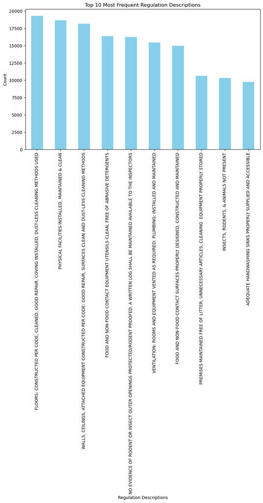

```python
top_10_descriptions.plot(kind='bar', figsize=(10, 6), color='skyblue')
plt.title('Top 10 Most Frequent Regulation Descriptions')
plt.xlabel('Regulation Descriptions')
plt.ylabel('Count')
plt.show()
```

```python
for sublist in df_cleaned.loc[57, 'regulation_descriptions']:
    print(sublist)
```

```
ADEQUATE HANDWASHING SINKS PROPERLY SUPPLIED AND ACCESSIBLE
THERMOMETERS PROVIDED & ACCURATE
INSECTS, RODENTS, & ANIMALS NOT PRESENT
INSECTS, RODENTS, & ANIMALS NOT PRESENT
CONTAMINATION PREVENTED DURING FOOD PREPARATION, STORAGE & DISPLAY
WAREWASHING FACILITIES: INSTALLED, MAINTAINED & USED; TEST STRIPS
NON-FOOD/FOOD CONTACT SURFACES CLEAN
PHYSICAL FACILITIES INSTALLED, MAINTAINED & CLEAN
PHYSICAL FACILITIES INSTALLED, MAINTAINED & CLEAN
PHYSICAL FACILITIES INSTALLED, MAINTAINED & CLEAN
PHYSICAL FACILITIES INSTALLED, MAINTAINED & CLEAN
```

```python
pd.Series(df_cleaned.loc[57, 'regulation_descriptions']).value_counts()
```

```
PHYSICAL FACILITIES INSTALLED, MAINTAINED & CLEAN                     4
INSECTS, RODENTS, & ANIMALS NOT PRESENT                               2
ADEQUATE HANDWASHING SINKS PROPERLY SUPPLIED AND ACCESSIBLE           1
THERMOMETERS PROVIDED & ACCURATE                                      1
CONTAMINATION PREVENTED DURING FOOD PREPARATION, STORAGE & DISPLAY    1
WAREWASHING FACILITIES: INSTALLED, MAINTAINED & USED; TEST STRIPS     1
NON-FOOD/FOOD CONTACT SURFACES CLEAN                                  1
Name: count, dtype: int64
```

# Identify whether any of these restaurants are repeat offenders (explore a combination of License; Business Name and Address variables to determine what is the best way to uniquely identify a business) and whether the violations are the same or different for these repeat offenses

```python
# Group the data by name and address
unique_buiz = df_cleaned.groupby(["DBA Name", "Address", "License #"]).agg({
    'regulation_descriptions': lambda x: x.tolist(),
    'Violations': 'count'
}).reset_index()

# Rename the 'Violations' column to 'count'
unique_buiz = unique_buiz.rename(columns={'Violations': 'count'})

# Display the resulting DataFrame
print(unique_buiz)
```

```
                           DBA Name                   Address  License #  \
0                      #1 CHOP SUEY           1907 W 87TH ST   2042372.0
1                      #1 CHOP SUEY    4307 W IRVING PARK RD   1970042.0
2                      #1 CHOP SUEY    4307 W IRVING PARK RD   2835290.0
3      #1 CHOP SUEY RESTAURANT, INC  7342 S STONY ISLAND AVE   2695112.0
4                     #1 WOK N ROLL           1408 E 53RD ST     58961.0
...                             ...                       ...        ...
21885            jaihind restaurant  6410-12 N CLAREMONT AVE   2017972.0
21886                   mi tortilla     3320 W lawrence BLDG   1990924.0
21887             rendezvous bistro      2656 W Lawrence AVE   2021807.0
21888                      stockton      4425 N Magnolia AVE   2058663.0
21889         tien giang restaurant          4925 N Broadway   2013912.0

                                 regulation_descriptions  count
0      [[NO EVIDENCE OF RODENT OR INSECT OUTER OPENIN...      3
1      [[PROCEDURES FOR RESPONDING TO VOMITING AND DI...      5
2      [[INSECTS, RODENTS, & ANIMALS NOT PRESENT, FOO...      1
3      [[FOOD PROPERLY LABELED; ORIGINAL CONTAINER, I...      1
4      [[NO EVIDENCE OF RODENT OR INSECT OUTER OPENIN...      5
...                                                  ...    ...
21885  [[FACILITIES TO MAINTAIN PROPER TEMPERATURE, O...      1
21886  [[NO EVIDENCE OF RODENT OR INSECT OUTER OPENIN...      1
21887  [[FACILITIES TO MAINTAIN PROPER TEMPERATURE, N...      2
21888  [[NO EVIDENCE OF RODENT OR INSECT OUTER OPENIN...      3
21889  [[NO EVIDENCE OF RODENT OR INSECT OUTER OPENIN...      3

[21890 rows x 5 columns]
```

```python
# Filter rows with count more than 1
repeat_offenders = unique_buiz[unique_buiz['count'] > 1]
repeat_offenders
```

|  | DBA Name | Address | License # | regulation_descriptions | count |
| --- | --- | --- | --- | --- | --- |
| 0 | #1 CHOP SUEY | 1907 W 87TH ST | 2042372.0 | [[NO EVIDENCE OF RODENT OR INSECT OUTER OPENIN... | 3 |
| 1 | #1 CHOP SUEY | 4307 W IRVING PARK RD | 1970042.0 | [[PROCEDURES FOR RESPONDING TO VOMITING AND DI... | 5 |
| 4 | #1 WOK N ROLL | 1408 E 53RD ST | 58961.0 | [[NO EVIDENCE OF RODENT OR INSECT OUTER OPENIN... | 5 |
| 9 | 1 N WACKER KITCHEN AND BAR | 1 N WACKER DR | 2550171.0 | [[FOOD-CONTACT SURFACES: CLEANED & SANITIZED, ... | 2 |
| 12 | 1,200 SQ.FT. - YEMEN RESTAURANT, INC. | 4748 N KENNETH AVE | 2088929.0 | [[SEWAGE AND WASTE WATER DISPOSAL, NO BACK SIP... | 3 |
| ... | ... | ... | ... | ... | ... |
| 21873 | Zoku Sushi | 1616 N KEDZIE AVE | 2575420.0 | [[ADEQUATE HANDWASHING SINKS PROPERLY SUPPLIED... | 3 |
| 21875 | bopNgrill | 921 W BELMONT AVE | 2398736.0 | [[POTENTIALLY HAZARDOUS FOOD MEETS TEMPERATURE... | 2 |
| 21887 | rendezvous bistro | 2656 W Lawrence AVE | 2021807.0 | [[FACILITIES TO MAINTAIN PROPER TEMPERATURE, N... | 2 |
| 21888 | stockton | 4425 N Magnolia AVE | 2058663.0 | [[NO EVIDENCE OF RODENT OR INSECT OUTER OPENIN... | 3 |
| 21889 | tien giang restaurant | 4925 N Broadway | 2013912.0 | [[NO EVIDENCE OF RODENT OR INSECT OUTER OPENIN... | 3 |

10879 rows × 5 columns

```python
repeat_offenders.loc[1, 'regulation_descriptions']
```

```
[['PROCEDURES FOR RESPONDING TO VOMITING AND DIARRHEAL EVENTS',
  'FOOD PROPERLY LABELED; ORIGINAL CONTAINER',
  'CONTAMINATION PREVENTED DURING FOOD PREPARATION, STORAGE & DISPLAY',
  'SINGLE-USE/SINGLE-SERVICE ARTICLES: PROPERLY STORED & USED',
  'FOOD & NON-FOOD CONTACT SURFACES CLEANABLE, PROPERLY DESIGNED, CONSTRUCTED & USED',
  'NON-FOOD/FOOD CONTACT SURFACES CLEAN',
  'PLUMBING INSTALLED; PROPER BACKFLOW DEVICES',
  'TOILET FACILITIES: PROPERLY CONSTRUCTED, SUPPLIED, & CLEANED',
  'PHYSICAL FACILITIES INSTALLED, MAINTAINED & CLEAN',
  'PHYSICAL FACILITIES INSTALLED, MAINTAINED & CLEAN',
  'ADEQUATE VENTILATION & LIGHTING; DESIGNATED AREAS USED',
  'PREVIOUS CORE VIOLATION CORRECTED'],
 ['NO EVIDENCE OF RODENT OR INSECT OUTER OPENINGS PROTECTED/RODENT PROOFED, A WRITTEN LOG SHALL BE MAINTAINED AVAILABLE TO THE INSPECTORS',
  'FOOD AND NON-FOOD CONTACT SURFACES PROPERLY DESIGNED, CONSTRUCTED AND MAINTAINED',
  'FOOD AND NON-FOOD CONTACT EQUIPMENT UTENSILS CLEAN, FREE OF ABRASIVE DETERGENTS',
  'WALLS, CEILINGS, ATTACHED EQUIPMENT CONSTRUCTED PER CODE: GOOD REPAIR, SURFACES CLEAN AND DUST-LESS CLEANING METHODS'],
 ['FOOD PROTECTED DURING STORAGE, PREPARATION, DISPLAY, SERVICE AND TRANSPORTATION',
  'NO EVIDENCE OF RODENT OR INSECT OUTER OPENINGS PROTECTED/RODENT PROOFED, A WRITTEN LOG SHALL BE MAINTAINED AVAILABLE TO THE INSPECTORS',
  'CLEAN MULTI-USE UTENSILS AND SINGLE SERVICE ARTICLES PROPERLY STORED: NO REUSE OF SINGLE SERVICE ARTICLES',
  'FOOD AND NON-FOOD CONTACT SURFACES PROPERLY DESIGNED, CONSTRUCTED AND MAINTAINED',
  'FOOD AND NON-FOOD CONTACT EQUIPMENT UTENSILS CLEAN, FREE OF ABRASIVE DETERGENTS',
  'FLOORS: CONSTRUCTED PER CODE, CLEANED, GOOD REPAIR, COVING INSTALLED, DUST-LESS CLEANING METHODS USED',
  'VENTILATION: ROOMS AND EQUIPMENT VENTED AS REQUIRED: PLUMBING: INSTALLED AND MAINTAINED',
  'FOOD (ICE) DISPENSING UTENSILS, WASH CLOTHS PROPERLY STORED'],
 ['PREVIOUS MINOR VIOLATION(S) CORRECTED 7-42-090',
  'FOOD AND NON-FOOD CONTACT SURFACES PROPERLY DESIGNED, CONSTRUCTED AND MAINTAINED',
  'FOOD AND NON-FOOD CONTACT EQUIPMENT UTENSILS CLEAN, FREE OF ABRASIVE DETERGENTS',
  'FLOORS: CONSTRUCTED PER CODE, CLEANED, GOOD REPAIR, COVING INSTALLED, DUST-LESS CLEANING METHODS USED',
  'WALLS, CEILINGS, ATTACHED EQUIPMENT CONSTRUCTED PER CODE: GOOD REPAIR, SURFACES CLEAN AND DUST-LESS CLEANING METHODS',
  'FOOD HANDLER REQUIREMENTS MET'],
 ['NO EVIDENCE OF RODENT OR INSECT OUTER OPENINGS PROTECTED/RODENT PROOFED, A WRITTEN LOG SHALL BE MAINTAINED AVAILABLE TO THE INSPECTORS',
  'FOOD AND NON-FOOD CONTACT EQUIPMENT UTENSILS CLEAN, FREE OF ABRASIVE DETERGENTS',
  'FLOORS: CONSTRUCTED PER CODE, CLEANED, GOOD REPAIR, COVING INSTALLED, DUST-LESS CLEANING METHODS USED',
  'WALLS, CEILINGS, ATTACHED EQUIPMENT CONSTRUCTED PER CODE: GOOD REPAIR, SURFACES CLEAN AND DUST-LESS CLEANING METHODS',
  'VENTILATION: ROOMS AND EQUIPMENT VENTED AS REQUIRED: PLUMBING: INSTALLED AND MAINTAINED']]
```

# Review the restaurants "Out of Business", is there an extended history of prior violations for these closed restaurants?

```python
# Creating "Out of Business" dataframe
out_of_business_df = df[df['Results'] == 'Out of Business']
out_of_business_df
```

|  | Inspection ID | DBA Name | AKA Name | License # | Facility Type | Risk | Address | City | State | Zip | Inspection Date | Inspection Type | Results | Violations | Latitude | Longitude | Location |
| --- | --- | --- | --- | --- | --- | --- | --- | --- | --- | --- | --- | --- | --- | --- | --- | --- | --- |
| 1 | 2587625 | TAQUERIA EL ARCO #3 EL POLLO FELIZ, INC. | EL POLLO CRIS CRIS #3 | 1964458.0 | Restaurant | Risk 1 (High) | 7023-7025 S PULASKI RD | CHICAGO | IL | 60629.0 | 01/04/2024 | Canvass | Out of Business | NaN | 41.765126 | -87.722279 | (41.765126421774134, -87.72227898862089) |
| 5 | 2587579 | SUBWAY | SUBWAY | 1719251.0 | Restaurant | Risk 1 (High) | 10354 S HALSTED ST | CHICAGO | IL | 60628.0 | 01/04/2024 | Canvass | Out of Business | NaN | 41.705296 | -87.642931 | (41.705296492547895, -87.64293095094614) |
| 8 | 2587465 | PROVARE CHICAGO | PROVARE CHICAGO | 2796734.0 | Restaurant | Risk 1 (High) | 1421 W CHICAGO AVE | CHICAGO | IL | 60642.0 | 12/28/2023 | Canvass | Out of Business | NaN | 41.896025 | -87.663272 | (41.89602502708334, -87.66327229348566) |
| 9 | 2587467 | ICOLDTEA | ICOLDTEA | 2886816.0 | Restaurant | Risk 2 (Medium) | 1122 W WILSON AVE | CHICAGO | IL | 60640.0 | 12/28/2023 | Canvass | Out of Business | NaN | 41.965497 | -87.658403 | (41.965497036127346, -87.65840280954839) |
| 26 | 2587279 | LEXINGTON BETTY SMOKE HOUSE | LEXINGTON BETTY SMOKE HOUSE | 2753635.0 | Restaurant | Risk 2 (Medium) | 1811 W HARRISON ST | CHICAGO | IL | 60612.0 | 12/20/2023 | Canvass | Out of Business | NaN | 41.874003 | -87.672010 | (41.874003274286764, -87.6720101808251) |
| ... | ... | ... | ... | ... | ... | ... | ... | ... | ... | ... | ... | ... | ... | ... | ... | ... | ... |
| 260096 | 231327 | MOUNTAIN VIEW CHEF INC | MOUNTAIN VIEW CHEF INC | 1145427.0 | Restaurant | Risk 1 (High) | 2168-2170 S ARCHER AVE | CHICAGO | IL | 60616.0 | 04/13/2010 | Out of Business | Out of Business | NaN | 41.853167 | -87.634461 | (41.85316719933144, -87.63446102872312) |
| 260248 | 251153 | QUALITY CROUTONS INC | QUALITY CROUTONS INC | 1384027.0 | NaN | Risk 2 (Medium) | 4031 S RACINE AVE | CHICAGO | IL | 60609.0 | 06/22/2010 | Out of Business | Out of Business | NaN | 41.820323 | -87.655713 | (41.82032251035431, -87.6557127671962) |
| 260331 | 251049 | CAMPBELL FOOD & LIQUOR INC | CAMPBELL FOOD & LIQUOR INC | 28448.0 | NaN | Risk 3 (Low) | 2459 W MADISON ST | CHICAGO | IL | 60612.0 | 06/17/2010 | Canvass | Out of Business | NaN | 41.881020 | -87.688671 | (41.881020491797024, -87.68867106150643) |
| 263472 | 67932 | Carter's Barbeque | Carter's Barbeque | 1933872.0 | NaN | Risk 1 (High) | 3801 W CHICAGO AVE | CHICAGO | IL | 60651.0 | 01/19/2010 | Canvass | Out of Business | NaN | 41.895303 | -87.721251 | (41.89530273536019, -87.72125106704621) |
| 264289 | 78343 | ROBERT EDWARDS | ROBERT EDWARDS | 8026.0 | NaN | Risk 2 (Medium) | 2558 E 79TH ST | CHICAGO | IL | 60649.0 | 03/11/2010 | Out of Business | Out of Business | NaN | 41.751904 | -87.561449 | (41.75190389254192, -87.5614493592654) |

22483 rows × 17 columns

```python
out_of_business_df = out_of_business_df.dropna(subset=['Violations'])

out_of_business_df.head(10)
```

|  | Inspection ID | DBA Name | AKA Name | License # | Facility Type | Risk | Address | City | State | Zip | Inspection Date | Inspection Type | Results | Violations | Latitude | Longitude | Location |
| --- | --- | --- | --- | --- | --- | --- | --- | --- | --- | --- | --- | --- | --- | --- | --- | --- | --- |
| 1837 | 2571310 | CHITOWN FUTBOL & SOCIAL | CHITOWN FUTBOL & SOCIAL | 2699095.0 | Restaurant | Risk 1 (High) | 2343 S THROOP ST | CHICAGO | IL | 60608.0 | 02/16/2023 | Canvass Re-Inspection | Out of Business | 56. ADEQUATE VENTILATION & LIGHTING; DESIGNATE... | 41.849377 | -87.658477 | (41.849377228107315, -87.65847731791494) |
| 1906 | 2570822 | CHECKERS/ RALLY'S | CHECKERS | 2704237.0 | Restaurant | Risk 1 (High) | 11449 S HALSTED ST | CHICAGO | IL | 60628.0 | 02/06/2023 | Canvass Re-Inspection | Out of Business | 49. NON-FOOD/FOOD CONTACT SURFACES CLEAN - Com... | 41.685459 | -87.642017 | (41.685458811028944, -87.64201677375817) |
| 2628 | 2564719 | STARBUCKS COFFEE #2261 | STARBUCKS COFFEE | 23071.0 | Restaurant | Risk 2 (Medium) | 233 S WACKER DR | CHICAGO | IL | 60606.0 | 10/03/2022 | Canvass | Out of Business | 16. FOOD-CONTACT SURFACES: CLEANED & SANITIZED... | 41.878560 | -87.636524 | (41.87856015362371, -87.63652387205532) |
| 8614 | 2312477 | BODY FACTORY NUTRITION | BODY FACTORY NUTRITION | 0.0 | FITNESS CENTER | Risk 2 (Medium) | 1500 W 51ST ST | CHICAGO | IL | 60609.0 | 09/18/2019 | Complaint Re-Inspection | Out of Business | 5. PROCEDURES FOR RESPONDING TO VOMITING AND D... | 41.801459 | -87.662410 | (41.801459089017484, -87.66241034937224) |
| 23915 | 1343463 | YASU CORPORATION | NaN | 2059522.0 | Catering | Risk 1 (High) | 4300 W LAKE ST | CHICAGO | IL | 60624.0 | 09/20/2013 | Canvass | Out of Business | 35. WALLS, CEILINGS, ATTACHED EQUIPMENT CONSTR... | 41.886001 | -87.733297 | (41.88600052434263, -87.73329707793616) |
| 37261 | 2578364 | 7-ELEVEN #25431 | 7-ELEVEN #25431 | 12327.0 | Grocery Store | Risk 2 (Medium) | 3407 N HALSTED ST | CHICAGO | IL | 60657.0 | 06/15/2023 | Canvass | Out of Business | 43. IN-USE UTENSILS: PROPERLY STORED - Comment... | 41.943854 | -87.649235 | (41.94385385221763, -87.64923480228471) |
| 46360 | 2565769 | MUSEUM OF SCIENCE & INDUSTRY - FINNEGANS ICE C... | MUSEUM OF SCIENCE & INDUSTRY - FINNEGANS ICE C... | 1224021.0 | Restaurant | Risk 2 (Medium) | 5700 S LAKE SHORE DR | CHICAGO | IL | 60637.0 | 10/21/2022 | Canvass | Out of Business | 55. PHYSICAL FACILITIES INSTALLED, MAINTAINED ... | 41.791420 | -87.580148 | (41.79142028209799, -87.58014776868883) |
| 50378 | 2565765 | ONE SMALL SNACK | ONE SMALL SNACK | 2803192.0 | Restaurant | Risk 1 (High) | 5700 S LAKE SHORE DR | CHICAGO | IL | 60637.0 | 10/21/2022 | Canvass | Out of Business | 36. THERMOMETERS PROVIDED & ACCURATE - Comment... | 41.791420 | -87.580148 | (41.79142028209799, -87.58014776868883) |
| 51675 | 2560368 | ADVANCED PETROLEUM | A P | 2803794.0 | GAS STATION | Risk 3 (Low) | 4701 S WESTERN BLVD | CHICAGO | IL | 60609.0 | 07/06/2022 | Canvass | Out of Business | 53. TOILET FACILITIES: PROPERLY CONSTRUCTED, S... | 41.808373 | -87.683726 | (41.8083731277443, -87.68372600471193) |
| 56716 | 2555633 | MR. CAPTAIN HOOK FISH AND CHICKEN AND GRILL | MR. CAPTAIN HOOK FISH AND CHICKEN AND GRILL | 2671718.0 | Restaurant | Risk 2 (Medium) | 4355 S COTTAGE GROVE AVE | CHICAGO | IL | 60653.0 | 05/11/2022 | Canvass Re-Inspection | Out of Business | 51. PLUMBING INSTALLED; PROPER BACKFLOW DEVICE... | 41.815197 | -87.606531 | (41.81519729173754, -87.60653088909952) |

```python
for index, row in out_of_business_df.iterrows():
    if not pd.isna(row['Violations']):
        print(f"\nRestaurant: {row['DBA Name']}")
        print("Extended History of Prior Violations:")
        print(row['Violations'])
```

```
Restaurant: CHITOWN FUTBOL & SOCIAL
Extended History of Prior Violations:
56. ADEQUATE VENTILATION & LIGHTING; DESIGNATED AREAS USED - Comments: 6-202.11  FOUND THE LIGHT SHIELD LOCATED IN THE FOOD PREP AREA MISSING. INSTRUCTED MANAGER TO REPLACE, | 57. ALL FOOD EMPLOYEES HAVE FOOD HANDLER TRAINING - Comments: 2-102.13  FOUND FOOD HANDLERS WITHOUT PROOF OF FOOD HANDLER TR…

Restaurant: CHECKERS/ RALLY'S
Extended History of Prior Violations:
49. NON-FOOD/FOOD CONTACT SURFACES CLEAN - Comments: 4-601.11(C) OBSERVED THE SHELVING UNITS IN THE FOOD PREP AREA WITH SLIGHT DEBRIS BUILD UP. INSTRUCTED TO CLEAN AND MAINTAIN SAID SHELVING UNITS.  | 57. ALL FOOD EMPLOYEES HAVE FOOD HANDLER TRAINING - Comments: 2-102.13 OBSERVED AN EXPIRED FOOD HAN…

Restaurant: STARBUCKS COFFEE #2261
Extended History of Prior Violations:
16. FOOD-CONTACT SURFACES: CLEANED & SANITIZED | 38. INSECTS, RODENTS, & ANIMALS NOT PRESENT

Restaurant: BODY FACTORY NUTRITION
Extended History of Prior Violations:
5. PROCEDURES FOR RESPONDING TO VOMITING AND DIARRHEAL EVENTS - Comments: SEE RETAIL FOOD LICENSE INSPECTION REPORT. | 51. PLUMBING INSTALLED; PROPER BACKFLOW DEVICES - Comments: SEE RETAIL FOOD LICENSE INSPECTION REPORT.

Restaurant: YASU CORPORATION
Extended History of Prior Violations:
35. WALLS, CEILINGS, ATTACHED EQUIPMENT CONSTRUCTED PER CODE: GOOD REPAIR, SURFACES CLEAN AND DUST-LESS CLEANING METHODS - Comments: THE WEST END COLUMN TO THE LEFT OF THE COOKING LINE HAS A DAMAGED BASEBOARD AND A 6 BY 8 INCH OPENING,   REPAIR THE GAP AND OPENING. | 38. VENTILATION: ROOMS AND EQUIP…

Restaurant: 7-ELEVEN #25431
Extended History of Prior Violations:
43. IN-USE UTENSILS: PROPERLY STORED - Comments: RELOCATE UTENSILS STORED FROM ABOVE THREE COMPARTMENT SINK (ALMOST TOUCHING COMPARTMENT) AND MAINTAIN.  | 47. FOOD & NON-FOOD CONTACT SURFACES CLEANABLE, PROPERLY DESIGNED, CONSTRUCTED & USED - Comments: DO NOT USE MILK CRATES TO STORE ITEM- REMOVE AN…

Restaurant: MUSEUM OF SCIENCE & INDUSTRY - FINNEGANS ICE CREAM PARLOR
Extended History of Prior Violations:
55. PHYSICAL FACILITIES INSTALLED, MAINTAINED & CLEAN - Comments: OBSERVED DUST ON THE ELECTRICAL CORD HOLDER ON THE KITCHEN CEILING; INSTRUCTED TO CLEAN.

Restaurant: ONE SMALL SNACK
Extended History of Prior Violations:
36. THERMOMETERS PROVIDED & ACCURATE - Comments: THE THERMOMETER FOUND IN THE HOT HOLDING UNIT IN THE SELF SERVE AREA HAD AN INCORRECT TEMPERATURE; INSTRUCTED TO REPLACE THERMOMETER. | 38. INSECTS, RODENTS, & ANIMALS NOT PRESENT - Comments: FOUND THE REAR EXIT DOOR LEADING TO THE STORAGE AREA FOR ON…

Restaurant: ADVANCED PETROLEUM
Extended History of Prior Violations:
53. TOILET FACILITIES: PROPERLY CONSTRUCTED, SUPPLIED, & CLEANED - Comments: OBSERVED NO SELF CLOSING DEVICE ON DOOR IN TOILET ROOM. INSTRUCTED TO PROVIDE AND MAINTAIN. | 55. PHYSICAL FACILITIES INSTALLED, MAINTAINED & CLEAN - Comments: OBSERVED DUST BUILD UP ON CEILING FAN IN TOILET ROOM. INSTRUCTE…

Restaurant: MR. CAPTAIN HOOK FISH AND CHICKEN AND GRILL
Extended History of Prior Violations:
51. PLUMBING INSTALLED; PROPER BACKFLOW DEVICES - Comments: OBSERVED LEAK AT THE 3 COMP SINK SPRAYER. NOTED HANDS SINKS WITH A SLOW DRAIN. MUST REPAIR AND MAINTAIN.

```

[output cut: 116 more lines]

```
Restaurant: BUBS GYROS
Extended History of Prior Violations:
33. FOOD AND NON-FOOD CONTACT EQUIPMENT UTENSILS CLEAN, FREE OF ABRASIVE DETERGENTS | 34. FLOORS: CONSTRUCTED PER CODE, CLEANED, GOOD REPAIR, COVING INSTALLED, DUST-LESS CLEANING METHODS USED | 35. WALLS, CEILINGS, ATTACHED EQUIPMENT CONSTRUCTED PER CODE: GOOD REPAIR, SURFACES CLEAN AND DUST-LESS CL…

Restaurant: HONEY BEAR NURSERY & KINDERGAR
Extended History of Prior Violations:
33. FOOD AND NON-FOOD CONTACT EQUIPMENT UTENSILS CLEAN, FREE OF ABRASIVE DETERGENTS - Comments: MUST DETAIL CLEAN AND SANITIZE INTERIOR OF ALL CUBBIE HOLES AND ALL TOYS. MUST CLEAN INTERIOR OF KITCHEN CABINETS,REFRIGERATOR,STOVE AND ALL SURFACES.    | 34. FLOORS: CONSTRUCTED PER CODE, CLEANED, GOOD …

Restaurant: THE BURGER BAR
Extended History of Prior Violations:
18. NO EVIDENCE OF RODENT OR INSECT OUTER OPENINGS PROTECTED/RODENT PROOFED, A WRITTEN LOG SHALL BE MAINTAINED AVAILABLE TO THE INSPECTORS - Comments: NOTED IMPROPER PEST CONTROL. NOTED APPROXIMATELY 10-15 MICE DROPPINGS IN THE HOT WATER HEATER CLOSET IN THE EMPLOYEE WASHROOM. MUST REMOVE DROPPINGS,…

Restaurant: KITH & KIN
Extended History of Prior Violations:
18. NO EVIDENCE OF RODENT OR INSECT OUTER OPENINGS PROTECTED/RODENT PROOFED, A WRITTEN LOG SHALL BE MAINTAINED AVAILABLE TO THE INSPECTORS | 30. FOOD IN ORIGINAL CONTAINER, PROPERLY LABELED: CUSTOMER ADVISORY POSTED AS NEEDED | 31. CLEAN MULTI-USE UTENSILS AND SINGLE SERVICE ARTICLES PROPERLY STORED…
```

### Food inspection data has 10+ years of history, do you see any changing trends in most common violations?

# Plot the results for top-5 most frequent violations over time

```python
df_cleaned['Inspection Date'] = pd.to_datetime(df_cleaned['Inspection Date'])
# Extract year from the inspection date
df_cleaned['Inspection Year'] = df_cleaned['Inspection Date'].dt.year
df_cleaned
```

|  | Inspection ID | DBA Name | AKA Name | License # | Facility Type | Risk | Address | City | State | Zip | Inspection Date | Inspection Type | Results | Violations | Latitude | Longitude | Location | regulation_descriptions | Inspection Year |
| --- | --- | --- | --- | --- | --- | --- | --- | --- | --- | --- | --- | --- | --- | --- | --- | --- | --- | --- | --- |
| 43 | 2587039 | SORA TEMAKERIA, LLC | SORA TEMAKERIA, LLC | 2569202.0 | Restaurant | Risk 1 (High) | 3508 W 26TH ST | CHICAGO | IL | 60623.0 | 2023-12-15 | Canvass Re-Inspection | Fail | 59. PREVIOUS PRIORITY FOUNDATION VIOLATION COR... | 41.844516 | -87.712776 | (41.84451619427469, -87.71277572197552) | [PREVIOUS PRIORITY FOUNDATION VIOLATION CORREC... | 2023 |
| 47 | 2586974 | CAFE 1850 | CAFE 1850 | 2590022.0 | Restaurant | Risk 1 (High) | 1850 W ROOSEVELT RD | CHICAGO | IL | 60608.0 | 2023-12-14 | Canvass | Fail | 10. ADEQUATE HANDWASHING SINKS PROPERLY SUPPLI... | 41.866906 | -87.673316 | (41.86690583756181, -87.6733159162735) | [ADEQUATE HANDWASHING SINKS PROPERLY SUPPLIED ... | 2023 |
| 57 | 2586823 | ALL ABOUT KIDS LEARNING ACADEMY | ALL ABOUT KIDS LEARNING ACADEMY | 2384881.0 | Children's Services Facility | Risk 1 (High) | 504-516 E 75TH ST | CHICAGO | IL | 60619.0 | 2023-12-12 | Canvass | Fail | 10. ADEQUATE HANDWASHING SINKS PROPERLY SUPPLI... | 41.758567 | -87.612451 | (41.758566800153645, -87.61245073862713) | [ADEQUATE HANDWASHING SINKS PROPERLY SUPPLIED ... | 2023 |
| 65 | 2586749 | BLISS BOWLS INC | BLISS BOWLS | 2943819.0 | Restaurant | Risk 2 (Medium) | 557 W DIVERSEY PKWY | CHICAGO | IL | 60614.0 | 2023-12-12 | License | Fail | 5. PROCEDURES FOR RESPONDING TO VOMITING AND D... | 41.932721 | -87.643354 | (41.932721491859006, -87.64335421876027) | [PROCEDURES FOR RESPONDING TO VOMITING AND DIA... | 2023 |
| 86 | 2586498 | STEVE'S LOUNGE | STEVE'S LOUNGE | 833.0 | Restaurant | Risk 1 (High) | 13200 S BALTIMORE AVE | CHICAGO | IL | 60633.0 | 2023-12-07 | Complaint Re-Inspection | Fail | 59. PREVIOUS PRIORITY FOUNDATION VIOLATION COR... | 41.655417 | -87.547291 | (41.655416650555715, -87.54729079495272) | [PREVIOUS PRIORITY FOUNDATION VIOLATION CORREC... | 2023 |
| ... | ... | ... | ... | ... | ... | ... | ... | ... | ... | ... | ... | ... | ... | ... | ... | ... | ... | ... | ... |
| 265633 | 120409 | SNOWIE | SNOWIE | 2026287.0 | Mobile Food Dispenser | Risk 3 (Low) | 2133 W LEXINGTON ST | CHICAGO | IL | 60612.0 | 2010-03-26 | License | Fail | 1. SOURCE SOUND CONDITION, NO SPOILAGE, FOODS ... | 41.872213 | -87.680199 | (41.87221345741769, -87.6801986217574) | [SOURCE SOUND CONDITION, NO SPOILAGE, FOODS PR... | 2010 |
| 265644 | 229217 | KAMEHACHI SUSHI CAFE | KAMEHACHI SUSHI CAFE | 1645648.0 | Restaurant | Risk 1 (High) | 311 S WACKER DR | CHICAGO | IL | 60606.0 | 2010-02-05 | Complaint | Fail | 29. PREVIOUS MINOR VIOLATION(S) CORRECTED 7-42... | 41.877792 | -87.636524 | (41.877791648104406, -87.63652434443534) | [PREVIOUS MINOR VIOLATION(S) CORRECTED 7-42-09... | 2010 |
| 265645 | 70273 | THE GREAT AMERICAN BAGEL | THE GREAT AMERICAN BAGEL (T3-H10) | 1879164.0 | Restaurant | Risk 1 (High) | 11601 W TOUHY AVE | CHICAGO | IL | 60666.0 | 2010-01-05 | Canvass | Fail | 9. WATER SOURCE: SAFE, HOT & COLD UNDER CITY P... | 42.008536 | -87.914428 | (42.008536400868735, -87.91442843927047) | [WATER SOURCE: SAFE, HOT & COLD UNDER CITY PRE... | 2010 |
| 265648 | 78350 | ACE'S SOUL FOOD CAFE, INC. | ACE'S SOUL FOOD CAFE, INC. | 1904903.0 | Restaurant | Risk 1 (High) | 432 E 63RD ST | CHICAGO | IL | 60637.0 | 2010-03-16 | Complaint | Fail | 18. NO EVIDENCE OF RODENT OR INSECT OUTER OPEN... | 41.780371 | -87.614355 | (41.78037142154735, -87.61435452532793) | [NO EVIDENCE OF RODENT OR INSECT OUTER OPENING... | 2010 |
| 265650 | 160278 | TIPAROS THAI RESTAURANT , INC. | TIPAROS THAI RESTAURANT | 40377.0 | Restaurant | Risk 1 (High) | 1540 N CLARK ST | CHICAGO | IL | 60610.0 | 2010-02-24 | Canvass | Fail | 29. PREVIOUS MINOR VIOLATION(S) CORRECTED 7-42... | 41.910610 | -87.631799 | (41.910610371780216, -87.63179897232193) | [PREVIOUS MINOR VIOLATION(S) CORRECTED 7-42-09... | 2010 |

48413 rows × 19 columns

```python
# Explode the 'regulation_descriptions' column to separate rows for each violation description
exploded_df = df_cleaned.explode('regulation_descriptions')

# Group the data by year and regulation description, then count occurrences
grouped_data = exploded_df.groupby(['Inspection Year', 'regulation_descriptions']).size().reset_index(name='count')

grouped_data.head(50)
```

|  | Inspection Year | regulation_descriptions | count |
| --- | --- | --- | --- |
| 0 | 2010 | * CERTIFIED FOOD MANAGER ON SITE WHEN POTENTIA... | 391 |
| 1 | 2010 | * INSPECTION REPORT SUMMARY DISPLAYED AND VISI... | 51 |
| 2 | 2010 | ADEQUATE NUMBER, CONVENIENT, ACCESSIBLE, DESIG... | 174 |
| 3 | 2010 | ADEQUATE NUMBER, CONVENIENT, ACCESSIBLE, PROPE... | 157 |
| 4 | 2010 | ADEQUATE NUMBER, CONVENIENT, ACCESSIBLE, PROPE... | 1 |
| 5 | 2010 | APPROPRIATE METHOD OF HANDLING OF FOOD (ICE) H... | 148 |
| 6 | 2010 | CLEAN MULTI-USE UTENSILS AND SINGLE SERVICE AR... | 303 |
| 7 | 2010 | CLEAN MULTI-USE UTENSILS AND SINGLE SERVICE AR... | 1 |
| 8 | 2010 | DISH MACHINES: PROVIDED WITH ACCURATE THERMOME... | 5 |
| 9 | 2010 | DISH WASHING FACILITIES: PROPERLY DESIGNED, CO... | 325 |
| 10 | 2010 | DISH WASHING FACILITIES: PROPERLY DESIGNED, CO... | 1 |
| 11 | 2010 | DISH WASHING FACILITIES: PROPERLY DESIGNED, CO... | 1 |
| 12 | 2010 | DISH WASHING FACILITIES: PROPERLY DESIGNED, CO... | 1 |
| 13 | 2010 | DISH WASHING FACILITIES: PROPERLY DESIGNED, CO... | 1 |
| 14 | 2010 | DISH WASHING FACILITIES: PROPERLY DESIGNED, CO... | 1 |
| 15 | 2010 | FACILITIES TO MAINTAIN PROPER TEMPERATURE | 470 |
| 16 | 2010 | FACILITIES TO MAINTAIN PROPER TEMPERATURE - Co... | 1 |
| 17 | 2010 | FACILITIES TO MAINTAIN PROPER TEMPERATURE - Co... | 1 |
| 18 | 2010 | FACILITIES TO MAINTAIN PROPER TEMPERATURE - Co... | 1 |
| 19 | 2010 | FACILITIES TO MAINTAIN PROPER TEMPERATURE - Co... | 1 |
| 20 | 2010 | FACILITIES TO MAINTAIN PROPER TEMPERATURE - Co... | 1 |
| 21 | 2010 | FACILITIES TO MAINTAIN PROPER TEMPERATURE - Co... | 1 |
| 22 | 2010 | FACILITIES TO MAINTAIN PROPER TEMPERATURE - Co... | 1 |
| 23 | 2010 | FLOORS: CONSTRUCTED PER CODE, CLEANED, GOOD RE... | 2317 |
| 24 | 2010 | FLOORS: CONSTRUCTED PER CODE, CLEANED, GOOD RE... | 1 |
| 25 | 2010 | FLOORS: CONSTRUCTED PER CODE, CLEANED, GOOD RE... | 1 |
| 26 | 2010 | FLOORS: CONSTRUCTED PER CODE, CLEANED, GOOD RE... | 1 |
| 27 | 2010 | FLOORS: CONSTRUCTED PER CODE, CLEANED, GOOD RE... | 1 |
| 28 | 2010 | FLOORS: CONSTRUCTED PER CODE, CLEANED, GOOD RE... | 1 |
| 29 | 2010 | FLOORS: CONSTRUCTED PER CODE, CLEANED, GOOD RE... | 1 |
| 30 | 2010 | FLOORS: CONSTRUCTED PER CODE, CLEANED, GOOD RE... | 1 |
| 31 | 2010 | FLOORS: CONSTRUCTED PER CODE, CLEANED, GOOD RE... | 1 |
| 32 | 2010 | FLOORS: CONSTRUCTED PER CODE, CLEANED, GOOD RE... | 1 |
| 33 | 2010 | FLOORS: CONSTRUCTED PER CODE, CLEANED, GOOD RE... | 1 |
| 34 | 2010 | FLOORS: CONSTRUCTED PER CODE, CLEANED, GOOD RE... | 1 |
| 35 | 2010 | FLOORS: CONSTRUCTED PER CODE, CLEANED, GOOD RE... | 1 |
| 36 | 2010 | FLOORS: CONSTRUCTED PER CODE, CLEANED, GOOD RE... | 1 |
| 37 | 2010 | FLOORS: CONSTRUCTED PER CODE, CLEANED, GOOD RE... | 1 |
| 38 | 2010 | FOOD (ICE) DISPENSING UTENSILS, WASH CLOTHS PR... | 120 |
| 39 | 2010 | FOOD AND NON-FOOD CONTACT EQUIPMENT UTENSILS C... | 1915 |
| 40 | 2010 | FOOD AND NON-FOOD CONTACT EQUIPMENT UTENSILS C... | 1 |
| 41 | 2010 | FOOD AND NON-FOOD CONTACT EQUIPMENT UTENSILS C... | 1 |
| 42 | 2010 | FOOD AND NON-FOOD CONTACT EQUIPMENT UTENSILS C... | 1 |
| 43 | 2010 | FOOD AND NON-FOOD CONTACT EQUIPMENT UTENSILS C... | 1 |
| 44 | 2010 | FOOD AND NON-FOOD CONTACT SURFACES PROPERLY DE... | 1777 |
| 45 | 2010 | FOOD AND NON-FOOD CONTACT SURFACES PROPERLY DE... | 1 |
| 46 | 2010 | FOOD AND NON-FOOD CONTACT SURFACES PROPERLY DE... | 1 |
| 47 | 2010 | FOOD AND NON-FOOD CONTACT SURFACES PROPERLY DE... | 1 |
| 48 | 2010 | FOOD AND NON-FOOD CONTACT SURFACES PROPERLY DE... | 1 |
| 49 | 2010 | FOOD AND NON-FOOD CONTACT SURFACES PROPERLY DE... | 1 |

```python
# Find the Top-5 most frequent violations for each year
top_5_per_year = grouped_data.groupby(['Inspection Year', 'regulation_descriptions'])['count'].sum() \
    .groupby('Inspection Year').nlargest(5).reset_index(level=0, drop=True).reset_index()

top_5_per_year.head()
```

|  | Inspection Year | regulation_descriptions | count |
| --- | --- | --- | --- |
| 0 | 2010 | FLOORS: CONSTRUCTED PER CODE, CLEANED, GOOD RE... | 2317 |
| 1 | 2010 | WALLS, CEILINGS, ATTACHED EQUIPMENT CONSTRUCTE... | 2302 |
| 2 | 2010 | VENTILATION: ROOMS AND EQUIPMENT VENTED AS REQ... | 1952 |
| 3 | 2010 | FOOD AND NON-FOOD CONTACT EQUIPMENT UTENSILS C... | 1915 |
| 4 | 2010 | NO EVIDENCE OF RODENT OR INSECT OUTER OPENINGS... | 1856 |

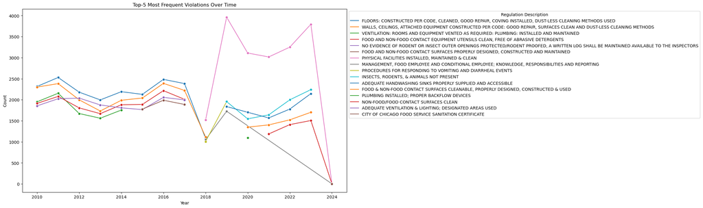

```python
import matplotlib.pyplot as plt
import seaborn as sns
# Plot the results for the Top-5 most frequent violations for each year
plt.figure(figsize=(14, 8))
sns.lineplot(data=top_5_per_year, x='Inspection Year', y='count', hue='regulation_descriptions', marker='o', palette='tab10')
plt.title('Top-5 Most Frequent Violations Over Time')
plt.xlabel('Year')
plt.ylabel('Count')
plt.legend(title='Regulation Description', bbox_to_anchor=(1, 1))
plt.show()
```

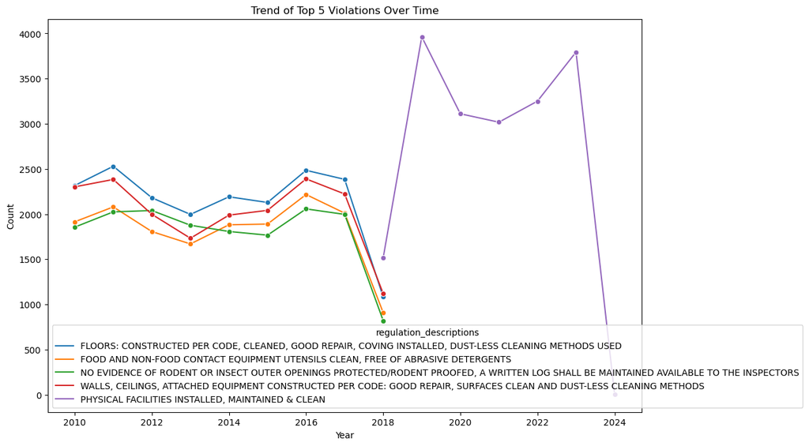

```python
import seaborn as sns
import matplotlib.pyplot as plt

# Find the overall Top-5 most frequent violations
top_5_overall = grouped_data.groupby('regulation_descriptions')['count'].sum().nlargest(5).reset_index()

# Filter the data for the top 5 overall violations
filtered_data = grouped_data[grouped_data['regulation_descriptions'].isin(top_5_overall['regulation_descriptions'])]

# Create a seaborn lineplot for the trend
plt.figure(figsize=(12, 8))
sns.lineplot(x='Inspection Year', y='count', hue='regulation_descriptions', data=filtered_data, marker='o')

# Set labels and title
plt.xlabel('Year')
plt.ylabel('Count')
plt.title('Trend of Top 5 Violations Over Time')

# Show the plot
plt.show()
```